# Vision and Strategy for LEGO Lab

2024-10-18

## Overview

The LEGO Serious Play system provides a platform for teaching

- innovation, entrepreneurship and team building skills

It will do so in an engaging environment

- that can potentially lead participants
- through a series of bite-sized educational chunks

**But – the unanswered question is “How?”**

## Motivation - Why the Lab is Important

Colombia (like most nations today) has a national need to produce more technology innovators and entrepreneurs

It is important that they come from local educational institutions because:

- they will have a deep understanding of the culture
- they will stay and contribute to the nation long-run
- projection of cultural and economic power outside the nation

## Motivation - Meeting the Challenge

Too often there are two main problems that discourage young minds from engaging in technology careers:

- lack of enticing pathways to technology education
- perceptions (largely incorrect) that such careers are drudging and not rewarding

**Can we change these perceptions and offer young minds a pathway to a future that matters?**

## Chain of Wealth Creation c. 2024

Creativity = new solutions to (customer) problems

Innovations = invention + commercialization

Entrepreneurship = Innovation + business model

**A Business is about Making a Customer** (Peter Drucker)

## Immediate Objective of LEGO Serious Play in the Lab

The goal of this ~2-hour LEGO Lab module is to teach participants about a particular subset of technical and organization skills

Through collaboration and creative problem-solving,

That explores how different dynamics can influence management styles, decision-making, and teamwork.

## Longer-term Objectives

I believe that the current *Innovation & Creativity Lab*

- can evolve into a generalized *simulation lab*
- potentially run mainly by automated workflows built around LLMs

I believe the ultimate objective should be an educational *creativity-innovation-entrepreneurship ecosystem*

- that can be the basis for a *Start-up Incubator*
- with strong *industry ties* and
- new *revenue streams* for UniRemington

## How I structure an Entrepreneurship Workout

- Elevator Pitch (25 seconds-25 words)
- How Much Money do you Need? (est. ROI) and When
- Customer (demographics, characteristics, motivation)
- Size of market and major competitors
- Your product + substitutes, competitors and complements
- Business model (Map Revenues vs. Costs over time) and benchmark businesses
- Vision, Milestones, Benchmarks
- Financial Projections: Timeline, ROI, Risk (be specific)

## Components of Entrepreneurship

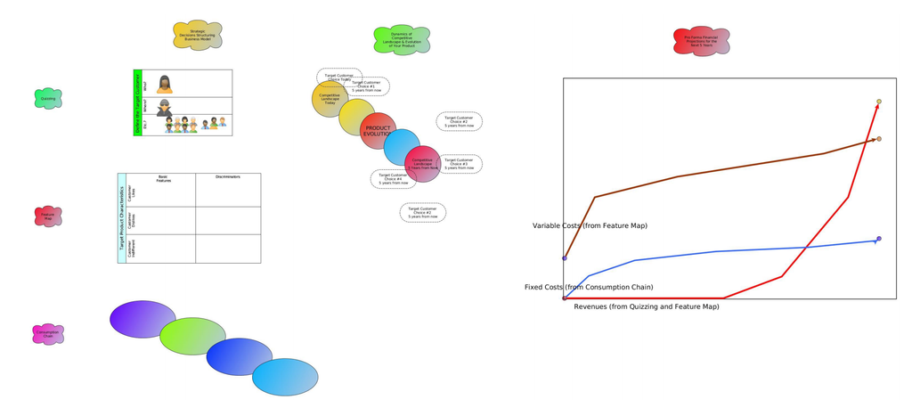

## Lab Structure

I envision a LEGO Lab that has a library of “Project Books” each with its own teaching objective

- e.g., one for accounting, one for finance, one for gender studies, and so forth
- with a goal of perhaps 20-30 of these supporting a wide range of courses

Each will be 1.5 to 2.5 hours in length, and will represent one class in a course offered at UniRemington

## Game Format (Lab Structure)

The format will borrow from “Escape Room” format

- creating a series of puzzle solving tasks ’
- that teach a particular topic

If you aren’t familiar with the various ‘tricks’ used in Escape Rooms,

- we should try it as a group

## Grading and Rubrics

Each Project Book will have a Rubric (set of learning objectives) and the grading associated with each

Each running of a class will be graded by students (self and team evaluations) and by the professor

These will support the module *Learning Objectives*

## Grading and Rubrics

These grades will be entered into a permanent database that will provide a one-week grade for the course

- as well as a permanent database
- that may be used for “progress statistics”
- for the University and interested government and accreditation organizations

## Example of Suggested Setup: *Gender Dynamics in the Workplace*

1. **Materials:**
   - Single box of LEGO s (including a mix of standard blocks, wheels, characters, accessories, etc.)
   - Task cards (with management or construction challenges)
   - Time-locked boxes or puzzles that require teamwork to solve
   - Small whiteboards or sheets for group discussions
   - A timer (set for however many minutes)
   - Gender role cards (optional, see below)

## Example of Suggested Setup (discuss)

1. **Teams:** Participants will be divided into teams of 3-5 people.

Each team will receive a mix of LEGO pieces and an initial puzzle to solve.

Optionally, each player can be assigned a gender role card that they must “perform” during the game.

These cards could represent stereotypical roles (e.g., assertive leader, supportive coordinator, etc.)

## Example of Suggested Setup (discuss)

1. **Game Areas:** Each team will be seated at their own table with the LEGO set and task materials.

There will be a shared “Brainstorming” area for the final challenge

- where all teams need to collaborate to complete the assigned task together.

## Game Structure:

Phase 1: **Building Under Pressure**

Each team is tasked with building a simple structure (e.g., a car or a bridge) using their LEGO pieces. However, they must do so under specific constraints:

- **Time Pressure**: Teams only have 10 minutes to complete their task.
- **Role Assignments**: Optionally, players must adhere to their role cards (if used). For example, one person might be instructed to take charge, while another must act as a passive observer.

## Reflection: Phase 1

After Phase 1, each team will have a 5-minute discussion reflecting on how gender dynamics played out during the challenge. Facilitators will guide them with questions like:

- Who led the task, and how?
- Were there any difficulties in communicating ideas?
- How did the roles affect teamwork?

## Game Structure:

Phase 2: **The Manager’s Dilemma**

Teams are now given a new set of tasks, but this time the tasks require the coordination of more complex structures. Here are some examples:

- **Task A**: Build a working crane using only half of the provided pieces.
- **Task B**: Construct a multi-level tower but every team member can only use one hand.

Each task is designed to challenge the team to rethink roles and manage their strengths effectively.

## Game Structure: Gender Bias

To explore gender biases in management, one team member will be chosen at random as the manager. After the challenge, teams will reflect on:

- Did team members trust the manager’s guidance?
- Did any bias or assumptions surface based on the manager’s gender?

## Game Structure:

Phase 3: **Collaboration**

For the final challenge, teams must unite to complete a large LEGO structure that will allow them to complete their assigned task. However, each team will have different resources (some teams will have more LEGO pieces, others less) and will need to share materials to complete the structure.

Only one spokesperson from each team can negotiate with others. The facilitator will oversee how resources are negotiated and how leadership shifts across the teams.

## Reflection: Phase 3

After the final challenge, participants will engage in a debrief discussion:

- How did the team dynamics change when working with limited resources?
- Did gender roles shift during this collaborative phase?
- What was learned about gender assumptions and effective task management?

## Game “Facilitator” (teacher) stays in the background but…

1. **Challenge Assumptions**: Encourage players to be mindful of how gender roles and biases may influence leadership and task management.
2. **Encourage Reflectlion**: Allow ample time for team discussions after each phase, helping participants think critically
3. **Role Rotation**: If time permits, have players switch roles during the different phases to experience different management and team dynamics.

## Take-aways:

Soft: a final group reflection, where players discuss:

- The impact of gender on task management and leadership
- How assumptions about gender roles influence decision-making and teamwork
- Strategies for fostering more equitable team dynamics in the workplace

Evaluation: performance of teams and individuals will be assessed:

- by individual students for other students and teams
- by teachers along with the facilitator

Evaluations will be permanently recorded in the lab database

## National Workforce - Why *Creativity-Innovation-Entrperneurship* is Important

The creation of a national workforce of entrepreneurs and technology experts

- is a priority in all nations
- because increasingly this is the reliable source of national wealth
- it attracts outside investors to set up companies in the country, and
- it improves the efficiency and scale of existing domestic companies

## National Workforce

Most importantly

- A modern, educated workforce
- creates a middle class

That middle-class is invested in the smooth operations

## Conclusion

Though the initial impression of education based on a “toy” (LEGOs) might seem preposterous

- it is exactly such challenging toy problems
- that modern problem solving intensive education is comprised of

## Conclusion

LEGO Serious Play approaches, supported by appropriate protocols and programs

Are one tool that can introduce important ideas in

- Entrepreneurship
- Team building
- Decision Making, Information & Communication
- Innovation and Creativity
- Other aspects of building a modern technology saavy organization

And doing it in a way that entices students to progress further in modern fields of endeavor